# Simulation to Find Latent Variable Effects with Small LVs

Tianyi Liu

2023-07-19

```r
source("a02_dSVA_functional.R")
source("s02_simulation_functions.R")
library(extraDistr)
library(statmod)
library(MASS)
library(dplyr)
library(tidyr)
library(statmod)
library(PCAtools)
library(paran)
library(sva)
library(DescTools)
library(microbenchmark)
set.seed(100)
```

## Simulations

In this simulation file, we look at under the model

$$\mathbf{Y}_{m \times n} = \mathbf{\Theta}_{m \times K} \mathbf{P}_{K
\times n} + \mathbf{Z}_{m \times p}\mathbf{D}_{p \times n} +
\mathbf{E}_{m \times n}$$
what happens if small increments are added to the gene expression in $\mathbf{Z}_{m \times p}$.

As a reminder, we solve the following constrained problem:

$$\mathbf{Y}_{m \times n} = \mathbf{\Theta}_{m \times K} \mathbf{P}_{K
\times n} + \mathbf{Z}_{m \times p}\mathbf{D}_{p \times n} +
\mathbf{E}_{m \times n}, \\
\mathbf{P}_{K \times n} \geq 0, \\
\mathbf{P}_{K \times n}^T \mathbf{1}_K = \mathbf{1}_n.$$

- $n$: number of samples;
- $m$: number of genes ($m >> n$);
- $K$: number of cell types;
- $p$: number of hidden factors;

For now, we assume $\mathbf{E}_{m \times n} = 0$.

There are other parameters to control the simulation scenarios:

- $p_{\rm sig}$: the proportion of signature genes;
- $\lambda$: controls the gene expression cell-type specificity;
- $\gamma$: controls the elevated effects of the latent variable on marker genes.

### Case 1: random direction of latent variable

Create an error-free model $\mathbf{E} = \mathbf{0}$ first:

```
  D[1, ] <- c(rep(0, floor(n/2)), rep(1, ceiling(n/2)))
  Z[, 1] <- W * rchisq(n = m, df = gamma * 200) + (1 - W) * rchisq(n = m, df = 200)
```

```r
n <- 20
m <- 2000
K <- 5
p <- 1
p_sig <- 0.5
lambda <- 5
```

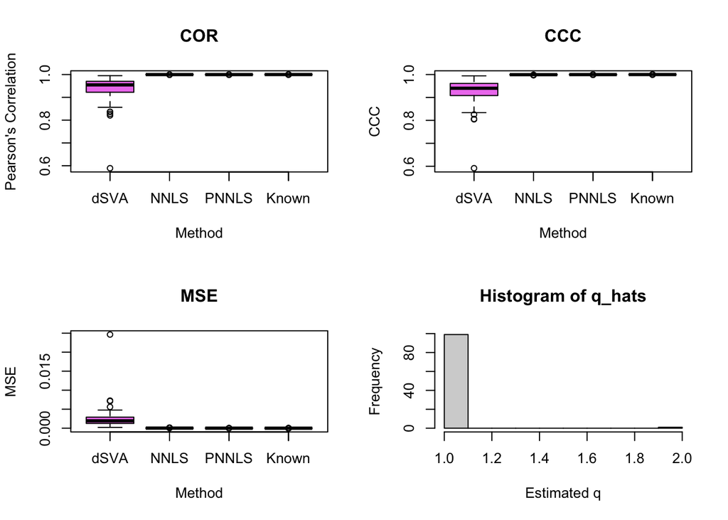